# Basic Usage

This vignette shows how to cluster the vertices of a weighted graph using the random walk method developed by Harel and Koren [1] with the `Rwclust` package using an example.

```r
library(Rwclust)
library(igraph)
```

## Introduction

The random walk algorithm is based on the concepts of *connected components* and *cut edges*. Let $G=(V, E)$ be a graph where $V$ is the set of vertices and $E$ is the set of edges. A *connected component* is a subset of vertices that are mutually reachable. A graph can have one connected component constituting the entire graph, or several connected components. If a graph has more than one connected component, the graph is said to be *disconnected*. In this context, the connected components correspond to clusters.

A set of *cut edges* is a set $E' \subset E$ such that $G-E$ is disconnected. Essentially, $E'$ contains a set of edges whose removal results in the creation of separate clusters of vertices.

The random walk algorithm finds a set of cut edges but "sharpening" the difference between the weights of edges which connect vertices in within a cluster and the weights of edges that run between clusters. All edges with weights below a certain user-defined threshold are deleted and the resulting connected components become the clusters.

The high-level steps in the algorithm are:

1. sharpen edge weights using random walks
2. select a cutoff using a histogram of the weights
3. delete edges below the cutoff and compute the connected components of the resulting graph

## Usage Example

We will use an example graph taken [1]. The data is contained in a dataframe. We use `igraph` to create a graph object a display it along with the edge weights.

```r
data(example1, package="Rwclust")
head(example1)
```

```
#>   from to weight
#> 1    1  2      1
#> 2    1  3      1
#> 3    1  4      1
#> 4    2  3      1
#> 5    3  4      1
#> 6    2  5      1
```

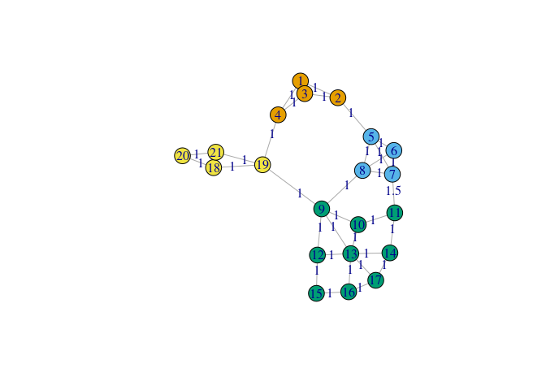

```r
labels <- c(1,1,1,1,2,2,2,2,3,3,3,3,3,3,3,3,3,4,4,4,4)

G <- igraph::graph_from_edgelist(as.matrix(example1[, c(1,2)]), directed=FALSE)
G <- igraph::set_edge_attr(G, "weight", value=example1$weight)

plot(G, edge.label=E(G)$weight, vertex.color=labels, layout=layout_with_fr)
```

#### 1. Sharpening Edge Weights

The `rwclust` function applies the edge-sharpening algorithm and returns a list containing a vector of the final weights and a sparse matrix representing the weighted adjacency matrix of the new graph. The `iter` parameter is the number of algorithm iterations and `k` is the maximum length of random walk to consider.

```r
result <- rwclust(example1, iter=6, k=3)
```

Next we plot the new weights. Notice how the weights connecting the clusters are 0 and all the other weights are larger than their original values.

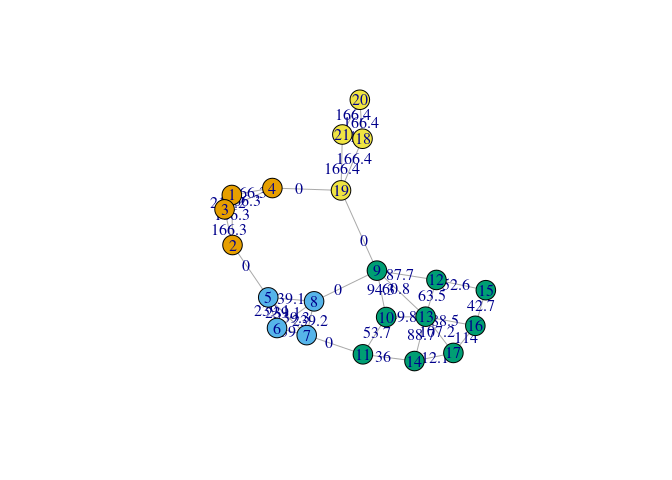

```r
G_sharpened <- igraph::graph_from_edgelist(as.matrix(example1[, c(1,2)]), directed=FALSE)
E(G_sharpened)$weights <- round(result$weights,1)
plot(G_sharpened, edge.label=E(G_sharpened)$weights, vertex.color=labels, layout=layout_with_fr)
```

#### 2. Plot the Histogram

Before edges are deleted and the connected components calculated, the user must select a cutoff. To do this we plot a histogram of the edge weights. Note that there appear to be several edges with very small edge weights. 25 seems to be an appropriate cutoff.

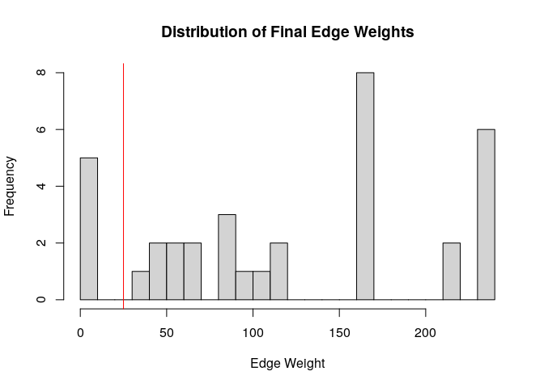

```r
hist(result$weights, breaks=20,
     main="Distribution of Final Edge Weights",
     xlab="Edge Weight")
abline(v=25, col="red")
```

#### 3. Delete Edges and Compute Components

The next step is to remove the edges that are below the threshold and compute the connected components.

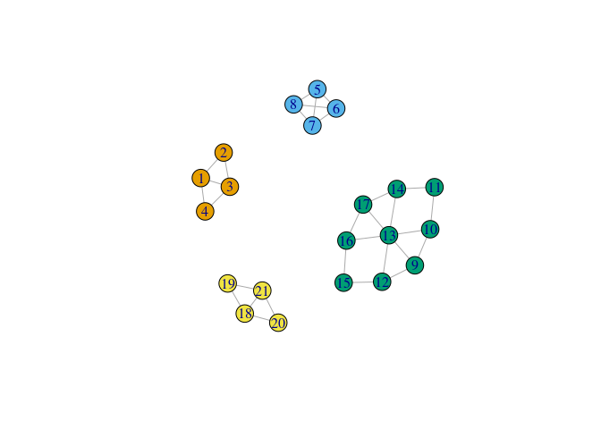

```r
# delete edges with weights below the threshold
edges_to_keep <- which(result$weights > 25)
example1_c <- example1[edges_to_keep, ]
example1_c$weight <- result$weights[edges_to_keep]

G_c <- igraph::graph_from_edgelist(as.matrix(example1_c[, c(1,2)]), directed=FALSE)

# compute the connected components
clusters <- igraph::components(G_c)$membership

plot(G_c, vertex.color=clusters)
```

## References

Harel, David, and Yehuda Koren. "On clustering using random walks." *International Conference on Foundations of Software Technology and Theoretical Computer Science*. Springer, Berlin, Heidelberg, 2001.